# pset10 - Dili Maduabum, Josh Bailey

## Problem 1

### 1.1

To formulate the problem as a MDP, we need to define its main components:

1. **States (S)**: The state represents the amount of money you currently have. Since you can have between $0 and $100, the state space is $ S = \{0, 1, 2, \ldots, 100\} $.
2. **Actions (A)**: The action in each state is the amount of money you choose to bet. For any state $ s $, where $ s \in \{1, 2, \ldots, 50\} $, the action space $ A(s) $ is $ \{0, 1, 2, \ldots, s\} $. When $ s > 50 $, you are constrained by the maximum winnable amount to $ A(s) = \{0, 1, 2, \ldots, 100 - s\} $. Note: Betting $0 means not playing, which might be a valid strategy in some formulations.
3. **Transition Probabilities (P)**:
   - Transition probabilities define the likelihood of moving from one state to another given an action. If you bet $ a $ dollars in state $ s $:
     - With probability $ p $ (success): You win the bet and move to state $ s + a $ (if $ s + a \leq 100 $, otherwise cap at 100).
     - With probability $ 1 - p $ (failure): You lose the bet and move to state $ s - a $.
   - Special cases are the boundaries:
     - If $ s = 0 $, no actions are possible except $ a = 0 $, and you remain in state 0.
     - If $ s = 100 $, you typically have no actions that affect your state as you have already won enough to leave the desert.
4. **Rewards (R)**:
   - The reward function is usually zero for all transitions except when reaching or starting from $100$. At state 100, a large positive reward $ R = 10 $ is given to reflect the utility of leaving the desert.
   - All other states and transitions might have a reward of 0, indicating no intrinsic value unless reaching the goal.
5. **Discount Factor (γ)**:
   - The discount factor $ \gamma $ here is $ 0.99 $, which models the urgency of leaving the desert due to the coin flip happening only once an hour.

### 1.2

#### Part (a): Linear Algebra Approach

To use linear algebra to evaluate the policy, we need to solve the system of linear equations derived from the Bellman equation for this specific policy: $ v(s) = \gamma (p \cdot v(s+1) + (1 - p) \cdot v(s-1)) $ for all states $ s $ where betting is possible, and $ v(0) = 0 $ and $ v(100) = 10 $ as boundary conditions.

We can construct a system of linear equations based on the above Bellman equations and solve it for $ v(s) $ for each state.

#### Part (b): Value Function Iteration

Value function iteration involves iteratively applying the Bellman update rule until convergence: $ v_{k+1}(s) = \gamma (p \cdot v_k(s+1) + (1 - p) \cdot v_k(s-1)) $ starting with an initial guess (usually $ v_0(s) = 0 $ for all $ s \neq 100 $ and $ v_0(100) = 10 $) and iterating until $ v_k $ stops changing significantly between iterations.

#### Linear Algebra Results:

- For $ p = 0.4 $:
  - Very low values close to zero for states near 50, increasing slightly as they approach 100.
- For $ p = 0.5 $:
  - Small but growing values, reflecting an equal chance of winning and losing.
- For $ p = 0.6 $:
  - Higher values indicating a better probability of reaching the goal due to a higher probability of winning.

#### Value Function Iteration Results:

- For $ p = 0.4 $, $ p = 0.5 $, and $ p = 0.6 $:
  - The values calculated show similar trends with those from the linear algebra approach, with increasing values towards the state 100, reflecting the increased likelihood of success as you move closer to the goal.

Both methods yield results that are consistent with each other, illustrating how the probability $ p $ influences the expected value of each state under this policy. The value of each state increases with the likelihood of winning the bet (higher $ p $), which matches the intuition that the strategy becomes more favourable as $ p $ increases.

```python
import numpy as np

def linear_algebra_approach(p, gamma=0.99):
    # Number of states
    n = 101
    # Initialize matrices
    A = np.zeros((n, n))
    b = np.zeros(n)
    # Boundary conditions
    A[0, 0] = 1
    A[100, 100] = 1
    b[100] = 10

    # Fill the matrix A based on the policy of betting $1
    for s in range(1, 100):
        A[s, s] = 1
        if s + 1 <= 100:
            A[s, s + 1] -= gamma * p
        if s - 1 >= 0:
            A[s, s - 1] -= gamma * (1 - p)

    # Solve the linear system
    v = np.linalg.solve(A, b)
    return v

def value_iteration(p, gamma=0.99, threshold=1e-6):
    n = 101
    v = np.zeros(n)
    v[100] = 10
    while True:
        delta = 0
        for s in range(1, 100):
            v_old = v[s]
            v_plus = v[s+1] if s+1 <= 100 else 0
            v_minus = v[s-1] if s-1 >= 0 else 0
            v[s] = gamma * (p * v_plus + (1 - p) * v_minus)
            delta = max(delta, abs(v_old - v[s]))
        if delta < threshold:
            break
    return v

# Evaluating policies for different p values
ps = [0.4, 0.5, 0.6]
results_la = {p: linear_algebra_approach(p) for p in ps}
results_vi = {p: value_iteration(p) for p in ps}

results_la, results_vi
```

```
({0.4: array([0.00000000e+00, 1.62018878e-19, 4.09138580e-19, 7.90149915e-19,
         1.38162020e-18, 2.30371502e-18, 3.74503188e-18, 6.00157869e-18,
         9.53795390e-18, 1.50833742e-17, 2.37823978e-17, 3.74314989e-17,
         5.88503904e-17, 9.24648487e-17, 1.45221507e-16, 2.28023704e-16,
         3.57985174e-16, 5.61967409e-16, 8.82131858e-16, 1.38465459e-15,
         2.17340471e-15, 3.41141384e-15, 5.35457436e-15, 8.40453167e-15,
         1.31917033e-14, 2.07055845e-14, 3.24992746e-14, 5.10104986e-14,
         8.00654784e-14, 1.25669804e-13, 1.97249771e-13, 3.09600778e-13,
         4.85945489e-13, 7.62733907e-13, 1.19717749e-12, 1.87907462e-12,
         2.94937170e-12, 4.62929639e-12, 7.26608486e-12, 1.14047545e-11,
         1.79007579e-11, 2.80968024e-11, 4.41003842e-11, 6.92194031e-11,
         1.08645896e-10, 1.70529219e-10, 2.67660496e-10, 4.20116516e-10,
         6.59409548e-10, 1.03500085e-09, 1.62452420e-09, 2.54983255e-09,
         4.00218479e-09, 6.28177842e-09, 9.85979963e-09, 1.54758163e-08,
         2.42906447e-08, 3.81262875e-08, 5.98425367e-08, 9.39280856e-08,
         1.47428330e-07, 2.31401635e-07, 3.63205068e-07, 5.70082063e-07,
         8.94793566e-07, 1.40445662e-06, 2.20441727e-06, 3.46002536e-06,
         5.43081186e-06, 8.52413333e-06, 1.33793714e-05, 2.10000915e-05,
         3.29614769e-05, 5.17359156e-05, 8.12040361e-05, 1.27456824e-04,
         2.00054612e-04, 3.14003179e-04, 4.92855402e-04, 7.73579580e-04,
         1.21420069e-03, 1.90579398e-03, 2.99131002e-03, 4.69512223e-03,
         7.36940422e-03, 1.15669233e-02, 1.81552959e-02, 2.84963219e-02,
         4.47274650e-02, 7.02036610e-02, 1.10190775e-01, 1.72954041e-01,
         2.71466466e-01, 4.26090318e-01, 6.68785952e-01, 1.04971794e+00,
         1.64762394e+00, 2.58608962e+00, 4.05909343e+00, 6.37110150e+00,
         1.00000000e+01]),
  0.5: array([0.00000000e+00, 1.93736988e-06, 3.91387854e-06, 5.96945545e-06,
         8.14562743e-06, 1.04863575e-05, 1.30389332e-05, 1.58549217e-05,
         1.89912117e-05, 2.25111625e-05, 2.64858842e-05, 3.09956744e-05,
         3.61316397e-05, 4.19975372e-05, 4.87118698e-05, 5.64102805e-05,
         6.52482929e-05, 7.54044526e-05, 8.70839346e-05, 1.00522688e-04,
         1.15992203e-04, 1.33804994e-04, 1.54320917e-04, 1.77954434e-04,
         2.05182990e-04, 2.36556657e-04, 2.72709247e-04, 3.14371114e-04,
         3.62383913e-04, 4.17717599e-04, 4.81490024e-04, 5.54989520e-04,
         6.39700926e-04, 7.37335583e-04, 8.49865909e-04, 9.79565242e-04,
         1.12905377e-03, 1.30135147e-03, 1.49993910e-03, 1.72882852e-03,
         1.99264378e-03, 2.29671446e-03, 2.64718342e-03, 3.05113083e-03,
         3.51671724e-03, 4.05334845e-03, 4.67186549e-03, 5.38476365e-03,
         6.20644491e-03, 7.15350889e-03, 8.24508821e-03, 9.50323497e-03,
         1.09533663e-02, 1.26247777e-02, 1.45512351e-02, 1.67716569e-02,
```

[output cut: 91 more lines]

```
          0.41821907,  0.4376211 ,  0.45792319,  0.47916708,  0.50139649,
          0.52465713,  0.54899686,  0.57446573,  0.60111613,  0.62900287,
          0.65818331,  0.68871748,  0.72066816,  0.75410109,  0.78908501,
          0.82569189,  0.86399702,  0.90407918,  0.9460208 ,  0.98990817,
          1.03583153,  1.08388535,  1.13416846,  1.18678428,  1.24184102,
          1.29945194,  1.35973551,  1.42281572,  1.48882233,  1.55789108,
          1.63016404,  1.70578985,  1.78492406,  1.86772943,  1.95437626,
          2.04504277,  2.13991544,  2.2391894 ,  2.34306883,  2.45176739,
          2.56550864,  2.68452652,  2.80906583,  2.9393827 ,  3.07574517,
          3.21843371,  3.36774179,  3.52397649,  3.68745917,  3.85852606,
          4.037529  ,  4.22483616,  4.42083279,  4.62592201,  4.84052563,
          5.06508504,  5.3000621 ,  5.54594011,  5.80322478,  6.07244528,
          6.35415533,  6.64893435,  6.95738861,  7.28015254,  7.61788998,
          7.97129559,  8.34109622,  8.72805247,  9.13296021,  9.55665224,
         10.        ])})
```

### 1.3

**Approach**:

1. **Initialization**: Start with an arbitrary policy, usually the safest bet, e.g., betting $1 at every state.
2. **Policy Evaluation**: Compute the value function for the current policy until it converges.
3. **Policy Improvement**: For each state, find a better policy by choosing an action that maximizes the expected return using the current value function.
4. **Convergence Check**: If the policy remains unchanged after an improvement step, convergence is achieved; otherwise, repeat from step 2.

#### Value Function Iteration

1. **Initialization**: Start with an arbitrary value function, often zero for all states.
2. **Iteration**: Update the value function using the Bellman Optimality Equation until the change is below a small threshold.
3. **Derive Policy**: Once the value function has converged, derive the policy by selecting the action that maximizes the expected return for each state using the converged value function.

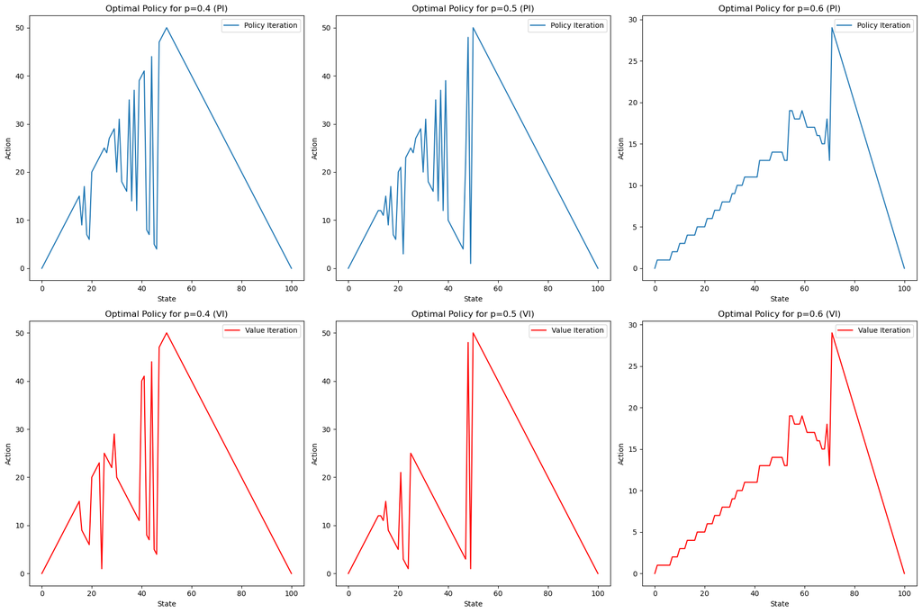

```python
import matplotlib.pyplot as plt

def policy_evaluation(policy, p, gamma=0.99, threshold=1e-6):
    n = 101
    v = np.zeros(n)
    v[100] = 10
    while True:
        delta = 0
        for s in range(1, 100):
            v_old = v[s]
            action = policy[s]
            v[s] = gamma * (p * v[min(s + action, 100)] + (1 - p) * v[max(s - action, 0)])
            delta = max(delta, abs(v_old - v[s]))
        if delta < threshold:
            break
    return v

def policy_improvement(v, p, gamma=0.99):
    n = 101
    new_policy = np.zeros(n, dtype=int)
    for s in range(1, 100):
        actions = range(min(s, 100 - s) + 1)
        action_returns = [gamma * (p * v[min(s + a, 100)] + (1 - p) * v[max(s - a, 0)]) for a in actions]
        new_policy[s] = actions[np.argmax(action_returns)]
    return new_policy

def policy_iteration(p):
    policy = np.ones(101, dtype=int)  # Start with a safe initial policy
    while True:
        v = policy_evaluation(policy, p)
        new_policy = policy_improvement(v, p)
        if np.array_equal(new_policy, policy):
            break
        policy = new_policy
    return policy, v

def value_iteration(p, gamma=0.99, threshold=1e-6):
    n = 101
    v = np.zeros(n)
    v[100] = 10
    policy = np.zeros(n, dtype=int)
    while True:
        delta = 0
        for s in range(1, 100):
            max_value = 0
            actions = range(min(s, 100 - s) + 1)
            action_values = [gamma * (p * v[min(s + a, 100)] + (1 - p) * v[max(s - a, 0)]) for a in actions]
            max_value = max(action_values)
            best_action = actions[np.argmax(action_values)]
            delta = max(delta, abs(v[s] - max_value))
            v[s] = max_value
            policy[s] = best_action
        if delta < threshold:
            break
    return policy, v

# Perform calcs for each p value
ps = [0.4, 0.5, 0.6]
policies_pi = {}
policies_vi = {}
for p in ps:
    policy_pi, _ = policy_iteration(p)
    policy_vi, _ = value_iteration(p)
    policies_pi[p] = policy_pi
    policies_vi[p] = policy_vi

# Plot
fig, axes = plt.subplots(2, 3, figsize=(18, 12))
for idx, p in enumerate(ps):
    axes[0, idx].plot(policies_pi[p], label='Policy Iteration')
    axes[0, idx].set_title(f'Optimal Policy for p={p} (PI)')
    axes[0, idx].set_xlabel('State')
    axes[0, idx].set_ylabel('Action')
    axes[0, idx].legend()

    axes[1, idx].plot(policies_vi[p], label='Value Iteration', color='red')
    axes[1, idx].set_title(f'Optimal Policy for p={p} (VI)')
    axes[1, idx].set_xlabel('State')
    axes[1, idx].set_ylabel('Action')
    axes[1, idx].legend()

plt.tight_layout()
plt.show()
```

## Problem 2

### 2.1

In the multi-armed bandit problem, each arm $ a $ of the bandit provides a reward distributed normally with a mean $ \mu_a = \frac{a}{10} $ and a variance of 1. To find the optimal arm:

#### Identifying the Optimal Arm

Since the mean of the reward from each arm increases linearly from arm 1 to arm 10 (i.e., $ \mu_1 = 0.1, \mu_2 = 0.2, \ldots, \mu_{10} = 1.0 $), the optimal arm is the one with the highest mean reward. Therefore, the optimal arm is arm 10 with $ \mu_{10} = 1.0 $.

#### Expected Sum of Rewards

If the agent plays the optimal arm for $ T = 200 $ rounds, the rewards for each play are independent and identically distributed as $ \mathcal{N}(1.0, 1) $. The expected reward for each play of the optimal arm is $ \mu_{10} = 1.0 $. Therefore, the expected sum of rewards after $ T $ rounds can be calculated by multiplying the expected reward of the optimal arm by the number of rounds:

$$ \text{Expected sum of rewards} = T \times \mu_{10} = 200 \times 1.0 = 200 $$

This result is intuitive because if the average reward per round is 1 (since $ \mu_{10} = 1 $), then over 200 rounds, you would expect to collect 200 units of reward in total, assuming you always choose the optimal arm.

### 2.2

#### Explore-then-Commit Algorithm

In the explore-then-commit (ETC) algorithm, we initially explore each of the arms a certain number of times $ m $ and then commit to the arm that appears to be the best based on the empirical means calculated from the exploration phase. After exploring, you commit to the arm with the highest average reward for the remaining rounds until $ T $.

The trade-off in choosing $ m $ is between exploration and exploitation. If $ m $ is small, you spend less time exploring, which might lead to committing to a suboptimal arm because of insufficient data about the true rewards of the arms. This can lead to higher regret if the initially chosen best arm turns out not to be the actual best arm. If $ m $ is large, you gather more information about each arm, potentially reducing the chance of committing to a suboptimal arm. However, excessive exploration consumes rounds that could have been spent harvesting rewards from the best arm, especially critical in environments with a limited number of rounds.

#### Simulation to Evaluate $ m $

To evaluate this strategy, we simulate the ETC algorithm 1000 times for each $ m $ from 1 to 20. We'll calculate the regret, which is the difference between the reward obtained by always playing the best arm and the reward obtained by the strategy. The optimal arm is known to be arm 10 with $ \mu_{10} = 1.0 $, so the total maximum possible reward for 200 rounds is $ 200 \times 1 = 200 $.

The plot displays the estimated regrets for different values of $ m $ using the explore-then-commit strategy across 1000 Monte Carlo simulations. Each point on the plot represents the average regret after 200 rounds when exploring each arm $ m $ times before committing to the one with the highest empirical mean.

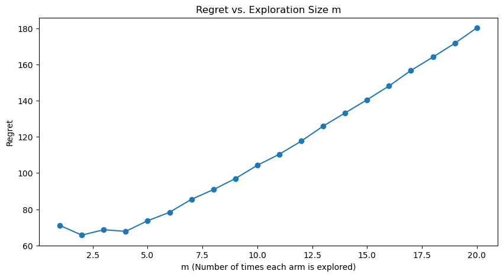

```python
# Parameters
num_arms = 10
mu_arms = np.linspace(0.1, 1, num_arms)
T = 200
num_simulations = 1000

def simulate_etc(m):
    total_rewards = np.zeros(num_simulations)
    for sim in range(num_simulations):
        # Exploration phase
        estimates = np.zeros(num_arms)
        for arm in range(num_arms):
            rewards = np.random.normal(mu_arms[arm], 1, m)
            estimates[arm] = np.mean(rewards)

        # Commit phase
        best_arm = np.argmax(estimates)
        commit_rewards = np.random.normal(mu_arms[best_arm], 1, T - num_arms * m)
        total_rewards[sim] = np.sum(rewards) + np.sum(commit_rewards)

    # Calculate average reward and regret
    average_reward = np.mean(total_rewards)
    regret = 200 - average_reward
    return regret

# Evaluate strategy for different values of m
ms = np.arange(1, 21)
regrets = np.array([simulate_etc(m) for m in ms])

# Plot the regrets for each m
plt.figure(figsize=(10, 5))
plt.plot(ms, regrets, marker='o')
plt.xlabel('m (Number of times each arm is explored)')
plt.ylabel('Regret')
plt.title('Regret vs. Exploration Size m')
plt.grid(False)
plt.show()
```

### 2.3

#### The $\varepsilon$-Greedy Algorithm

In the $\varepsilon$-greedy algorithm for the multi-armed bandit problem, the strategy is to choose the best-known arm (one with the highest estimated average reward) most of the time but explore randomly with a probability of $\varepsilon$. Specifically, with probability $1 - \varepsilon$, choose the arm with the highest estimated reward, and with probability $\varepsilon$, choose an arm randomly. This approach balances exploration and exploitation, where $\varepsilon$ controls the extent of exploration.

We simulate the $\varepsilon$-greedy strategy for the specified $\varepsilon$ values (0.1, 0.2, 0.5, 0.9, 0.95, 0.99) using 1000 Monte Carlo simulations. The performance will be measured by calculating the regret, which is the difference in reward between always playing the best arm (arm with $\mu_{10} = 1.0$) and the strategy outcome over 200 rounds.

The plot illustrates the estimated regrets for various values of $\varepsilon$ using the $\varepsilon$-greedy strategy across 1000 Monte Carlo simulations. Each point represents the average regret associated with a specific level of exploration ($\varepsilon$) over 200 rounds.

- As $\varepsilon$ increases, the regret initially decreases but then starts to increase significantly as $\varepsilon$ approaches 1. This trend highlights how the $\varepsilon$-greedy approach works, in that:
  - Lower $\varepsilon$ (e.g., 0.1) tends to favor exploitation, leading to lower regret if the best arm is identified early.
  - Moderate $\varepsilon$ provides a balance between exploration and exploitation, potentially achieving lower regret by ensuring that the best arm is consistently identified without excessively compromising on the exploitation of this knowledge.
  - High $\varepsilon$ (approaching 1) leads to excessive exploration, which means the strategy behaves almost randomly, thus increasing regret as fewer opportunities are used to exploit the best-known arm.

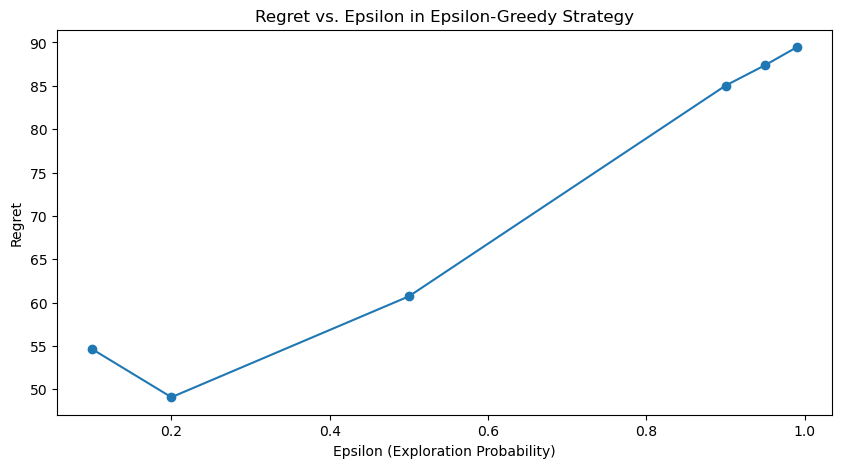

```python
# Parameters
num_arms = 10
mu_arms = np.linspace(0.1, 1, num_arms)
T = 200
num_simulations = 1000
epsilons = [0.1, 0.2, 0.5, 0.9, 0.95, 0.99]

def simulate_epsilon_greedy(epsilon):
    total_rewards = np.zeros(num_simulations)
    for sim in range(num_simulations):
        estimates = np.zeros(num_arms)
        counts = np.zeros(num_arms)
        rewards = np.zeros(T)

        for t in range(T):
            if np.random.rand() < epsilon:
                chosen_arm = np.random.choice(num_arms)
            else:
                chosen_arm = np.argmax(estimates)

            # Simulate the reward based on chosen arm
            reward = np.random.normal(mu_arms[chosen_arm], 1)
            rewards[t] = reward
            counts[chosen_arm] += 1

            # Update the estimate of the chosen arm
            estimates[chosen_arm] += (reward - estimates[chosen_arm]) / counts[chosen_arm]

        total_rewards[sim] = np.sum(rewards)

    # Calculate average reward and regret
    average_reward = np.mean(total_rewards)
    regret = 200 - average_reward
    return regret

# Evaluate strategy for different values of epsilon
regrets = np.array([simulate_epsilon_greedy(epsilon) for epsilon in epsilons])

# Plot the regrets for each epsilon
plt.figure(figsize=(10, 5))
plt.plot(epsilons, regrets, marker='o')
plt.xlabel('Epsilon (Exploration Probability)')
plt.ylabel('Regret')
plt.title('Regret vs. Epsilon in Epsilon-Greedy Strategy')
plt.grid(False)
plt.show()
```

### 2.4

Given the Gaussian distribution of rewards with a known variance of 1, we can utilize properties from the normal distribution to derive the confidence bound $ C(\delta) $. This value represents the margin by which the true mean $ \mu_a $ of the rewards from arm $ a $ might be greater than the observed average $ \hat{\mu}_a $ with a probability at most $ \delta $.

To derive $ C(\delta) $ based on the number of observations $ n_a $ and a confidence level $ \delta $, we use the fact that the sample mean of a normally distributed random variable $ X \sim N(\mu, \sigma^2) $ also follows a normal distribution:

$$ \hat{\mu}_a \sim N\left(\mu_a, \frac{1}{n_a}\right) $$

This means that $ \sqrt{n_a}(\hat{\mu}_a - \mu_a) $ follows a standard normal distribution $ N(0, 1) $. Using the cumulative distribution function of the standard normal distribution, we find $ z $ such that:

$$ 1 - \Phi(z) = \delta \implies z = \Phi^{-1}(1-\delta) $$

Thus, $ C(\delta) $ can be defined as:

$$ C(\delta) = \frac{z}{\sqrt{n_a}} $$

Where $ z = \Phi^{-1}(1-\delta) $ and $ \Phi^{-1} $ is the quantile function of the standard normal distribution.

#### UCB algorithm

The UCB algorithm uses an optimistic estimate of each arm's potential by considering both the empirical mean and a confidence bound that decreases with the number of times the arm has been played. The arm chosen is the one with the highest upper confidence bound:

$$ a_t = \arg\max_a \left(\hat{\mu}_a + C_t(\delta)\right) $$

Where $ C_t(\delta) $ adjusts over time based on the number of times arm $ a $ has been played and the chosen $ \delta $.

The plots illustrate how arms are selected over time using the UCB algorithm for different fixed values of $ \delta $ and a time-dependent $ \delta_t $. Each graph represents the arm chosen in each round, demonstrating the evolution of the algorithm's preferences based on its exploration and confidence calculations.

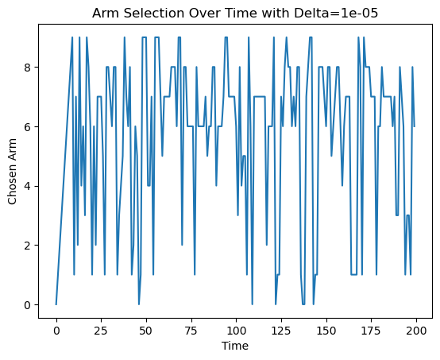

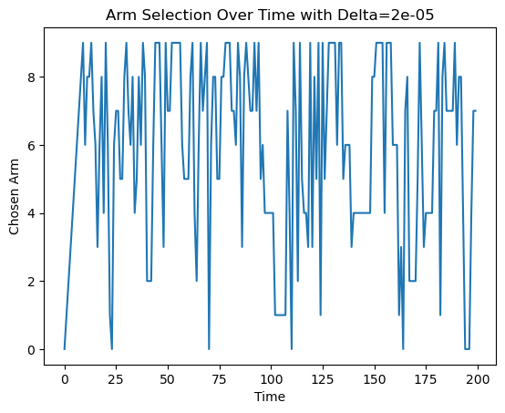

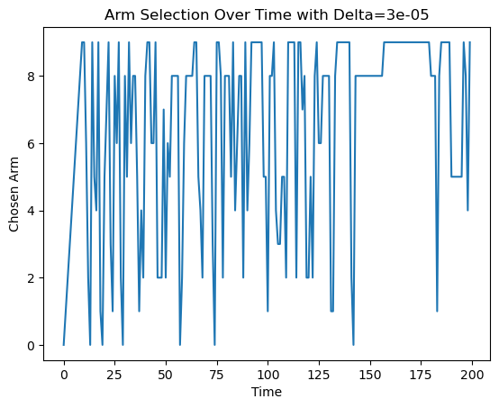

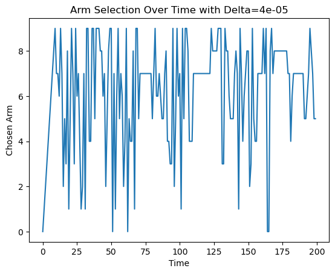

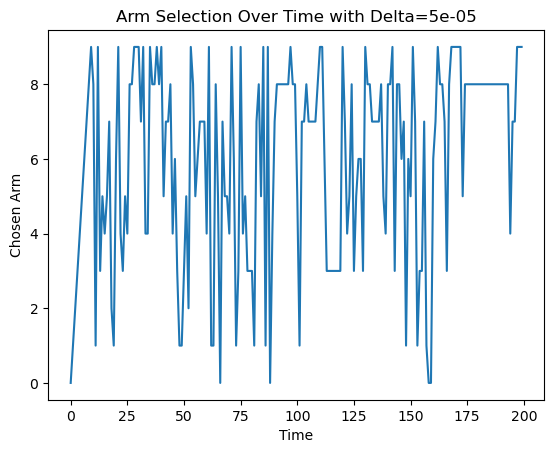

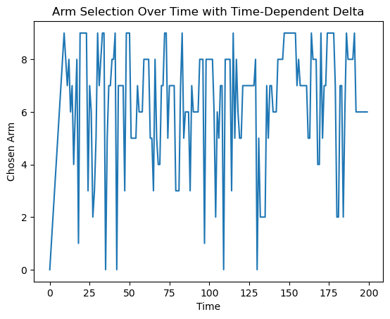

```python
import scipy.stats as stats

def ucb(num_arms, T, delta_func, mu_arms):
    counts = np.zeros(num_arms)  # Counts of selections for each arm
    estimates = np.zeros(num_arms)  # Estimated means of rewards for each arm
    total_rewards = 0
    selected_arms = np.zeros(T)

    # Initial exploration of each arm
    for a in range(num_arms):
        reward = np.random.normal(mu_arms[a], 1)
        counts[a] += 1
        estimates[a] = reward  # Initial estimate is just the first reward
        total_rewards += reward
        selected_arms[a] = a

    # UCB selection process
    for t in range(num_arms, T):
        delta = delta_func(t)
        confidence_bounds = stats.norm.ppf(1 - delta / 2) / np.sqrt(counts)
        ucb_values = estimates + confidence_bounds
        chosen_arm = np.argmax(ucb_values)
        reward = np.random.normal(mu_arms[chosen_arm], 1)
        counts[chosen_arm] += 1
        estimates[chosen_arm] += (reward - estimates[chosen_arm]) / counts[chosen_arm]
        total_rewards += reward
        selected_arms[t] = chosen_arm

    return total_rewards, selected_arms

# Setting parameters
num_arms = 10
mu_arms = np.linspace(0.1, 1, num_arms)
T = 200
deltas = [1e-5, 2e-5, 3e-5, 4e-5, 5e-5]
delta_t_func = lambda t: 1 / (1 + t * np.log(t))

# Running simulations for fixed deltas and plot
for delta in deltas:
    total_reward, selected_arms = ucb(num_arms, T, lambda t: delta, mu_arms)
    plt.figure()
    plt.plot(selected_arms)
    plt.title(f'Arm Selection Over Time with Delta={delta:.0e}')
    plt.xlabel('Time')
    plt.ylabel('Chosen Arm')
    plt.show()

# Running simulation for time-dependent delta and plot
total_reward_t, selected_arms_t = ucb(num_arms, T, delta_t_func, mu_arms)
plt.figure()
plt.plot(selected_arms_t)
plt.title('Arm Selection Over Time with Time-Dependent Delta')
plt.xlabel('Time')
plt.ylabel('Chosen Arm')
plt.show()
```

## Problem 3

### 3.1

For this problem, we calculate the expected reward based on the known probabilities of the coin showing heads or tails and the associated utilities. Here, the expected utility is straightforward since you win $1$ for heads and lose $1$ for tails.

Given the prior probabilities for the success probability $ p $:

- $ p = 0.2 $ with probability 0.51
- $ p = 0.8 $ with probability 0.49

The expected reward for a single coin flip can be computed by averaging the expected outcomes, weighted by their probabilities:

$$ \text{Expected Reward} = E[\text{Reward}] = 1 \times P(\text{Heads}) + (-1) \times P(\text{Tails}) $$

Where:

- $ P(\text{Heads}) = 0.2 \times 0.51 + 0.8 \times 0.49 $
- $ P(\text{Tails}) = 1 - P(\text{Heads}) $

The expected reward from flipping the coin once, given the prior probabilities and the values of heads and tails, is approximately $-0.012$. This negative value indicates that, on average, you would expect to lose about 1.2 cents per flip.

*Given that the expected reward is negative, we would not flip the coin even once.*

```python
# Given probabilities and their weights
p_head_1 = 0.2
prob_1 = 0.51
p_head_2 = 0.8
prob_2 = 0.49

# Calc the probability of getting a head
P_Heads = p_head_1 * prob_1 + p_head_2 * prob_2

# Probability of tails is 1 minus the probability of heads
P_Tails = 1 - P_Heads

# Expected reward
expected_reward = P_Heads * 1 + P_Tails * (-1)
expected_reward
```

```
-0.01200000000000001
```

### 3.2

Now we have the option to flip the coin once, observe the result, and then decide whether to flip it a second time. To determine whether we should proceed with flipping the coin once and possibly a second time, we can use Bayesian updating and backwards induction, which allows us to calculate the expected utility of each decision step.

#### 1: Initial Expected Reward

From the prior:

- $ p = 0.2 $ with probability 0.51
- $ p = 0.8 $ with probability 0.49

As calculated previously, the initial expected reward from flipping the coin once is approximately $-0.012$.

#### 2: Update Beliefs After First Flip

After the first flip, update the probabilities of $ p $ based on whether the result is heads or tails. The updates use Bayesian updating, reflecting how the observed outcome (heads or tails) affects our beliefs about the value of $ p $. If heads is observed, update the belief that $ p = 0.8 $ becomes more likely. If tails is observed, update the belief that $ p = 0.2 $ becomes more likely.

**Updated probabilities**:

- Let $ P(H) $ be the probability of heads based on the prior, $ P(H) = 0.494 $ (as calculated before).
- Let $ P(p = 0.8 | H) $ be the posterior probability of $ p = 0.8 $ given heads.
- Let $ P(p = 0.2 | H) $ be the posterior probability of $ p = 0.2 $ given heads, and similarly for tails.

Using Bayes' Rule:

- $ P(p = 0.8 | H) = \frac{P(H | p = 0.8) P(p = 0.8)}{P(H)} = \frac{0.8 \times 0.49}{0.494} $
- $ P(p = 0.2 | H) = \frac{P(H | p = 0.2) P(p = 0.2)}{P(H)} = \frac{0.2 \times 0.51}{0.494} $

And the same for tails.

#### 3: Whether to Flip a Second Time

The updated probabilities and expected rewards for flipping a second time are:

**If Heads is Observed:**

- $ P(p = 0.8 | H) \approx 0.794 $
- $ P(p = 0.2 | H) \approx 0.206 $
- **Expected Reward for Second Flip Given Heads:** $ 0.794 - 0.206 = 0.587 $

**If Tails is Observed:**

- $ P(p = 0.8 | T) \approx 0.194 $
- $ P(p = 0.2 | T) \approx 0.806 $
- **Expected Reward for Second Flip Given Tails:** $ -0.194 + 0.806 = 0.613 $

Based on the calculated expected rewards:

- **After Observing Heads:** The expected reward is approximately 0.587. Since this value is positive, it is advisable to flip the coin a second time if heads is observed on the first flip.
- **After Observing Tails:** The expected reward is approximately 0.613. Since this value is also positive, it is advisable to flip the coin a second time if tails is observed on the first flip.

*Given the Bayesian updates and the expected rewards for the second flip, we should flip the coin once and, regardless of whether the outcome is heads or tails, proceed to flip it a second time.*

Both updated scenarios (heads or tails observed first) lead to a positive expected reward for the second flip, suggesting that continued play is beneficial.

```python
# Given prior probabilities and initial probability of h
P_p_08 = 0.49
P_p_02 = 0.51
P_Heads = 0.494  # From prior calc
P_Tails = 1 - P_Heads

# Bayesian updates based on observing h or t
P_p_08_given_H = (0.8 * P_p_08) / P_Heads
P_p_02_given_H = (0.2 * P_p_02) / P_Heads

P_p_08_given_T = (0.2 * P_p_08) / P_Tails
P_p_02_given_T = (0.8 * P_p_02) / P_Tails

# Expected rewards after observing h or t
expected_reward_given_H = P_p_08_given_H * 1 + P_p_02_given_H * (-1)
expected_reward_given_T = P_p_08_given_T * (-1) + P_p_02_given_T * 1

# Results
P_p_08_given_H, P_p_02_given_H, expected_reward_given_H, P_p_08_given_T, P_p_02_given_T, expected_reward_given_T
```

```
(0.7935222672064778,
 0.20647773279352227,
 0.5870445344129556,
 0.19367588932806323,
 0.8063241106719368,
 0.6126482213438735)
```